# a3_task3_iris_foxfoot

Iris Foxfoot

10/31/2020

# **Section 1: size comparisons of purple and red urchins**

## 1. Exploratory data vizualization

### Read in the data

```r
sb_urchins <- read.csv(here("data", "urchins.csv"))
```

### Faceted histogram

Use geom_histogram() and facet_wrap()

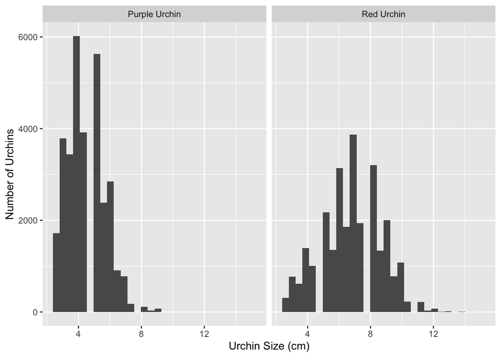

```r
ggplot(data = sb_urchins, aes(x = SIZE)) + geom_histogram() + facet_wrap(~COMMON_NAME) + labs(x = "Urchin Size (cm)", y = "Number of Urchins")
```

### Boxplot

Use geom_boxplot() with common name on the x-axis and size on the y-axis

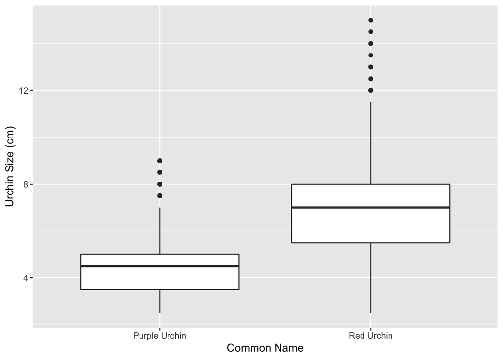

```r
ggplot(data = sb_urchins, aes(x = COMMON_NAME, y = SIZE)) + geom_boxplot() + labs(x= "Common Name", y = "Urchin Size (cm)")
```

## 2. Descriptive Statistics Table

Create a summary table with mean, median, standard devaition, and sample size for purple and red urchins. Use groub_by() and summarize()

```r
sb_urchins %>%
  group_by(COMMON_NAME) %>%
  summarise(mean(SIZE), median(SIZE), sd(SIZE), n()) %>%
  kbl() %>%
  kable_classic(html_font = "Cambria")
```

| COMMON_NAME | mean(SIZE) | median(SIZE) | sd(SIZE) | n() |
| --- | --- | --- | --- | --- |
| Purple Urchin | 4.469797 | 4.5 | 1.175264 | 31805 |
| Red Urchin | 6.776489 | 7.0 | 1.891343 | 27408 |

# **Section 2. Explore Purple Urchins by Site and Year**

## 1. Create a subset called “purple_urchins”

Filter to only include observations for purple urchins Convert the date to class “Date” Create a new column that only contains the year Create a new column called site_full that contains the full name (not abbreviation) for each of the five sites

```r
purple_urchins <- sb_urchins %>%
  filter(COMMON_NAME == "Purple Urchin") %>%
  mutate(date = mdy(DATE)) %>%
  mutate(year = year(date)) %>%
  mutate(site_full = case_when(
   SITE == "NAPL" ~ "Naples Reef",
  SITE == "AQUE" ~ "Arroyo Quemado Reef",
   SITE == "CARP" ~ "Carpinteria Reef",
  SITE == "MOHK" ~ "Mohawk Reef",
  SITE == "IVEE" ~ "Isla Vista Reef"))
  #purple_urchins$year <- as.Date(purple_urchins$year)
```

## 2. Make a Summary Table

Make a summary Table containing the total number of purple urchins observed by site and year using the count() function

```r
purple_urchins_tbl <- purple_urchins %>%
  group_by(site_full, year) %>%
  count()
kbl(purple_urchins_tbl) %>%
  kable_classic(html_font = "Cambria")
```

| site_full | year | n |
| --- | --- | --- |
| Arroyo Quemado Reef | 2008 | 67 |
| Arroyo Quemado Reef | 2009 | 926 |
| Arroyo Quemado Reef | 2010 | 921 |
| Arroyo Quemado Reef | 2011 | 887 |
| Arroyo Quemado Reef | 2012 | 764 |
| Arroyo Quemado Reef | 2013 | 434 |
| Arroyo Quemado Reef | 2014 | 410 |
| Arroyo Quemado Reef | 2015 | 400 |
| Arroyo Quemado Reef | 2016 | 342 |
| Arroyo Quemado Reef | 2017 | 406 |
| Arroyo Quemado Reef | 2018 | 408 |
| Arroyo Quemado Reef | 2019 | 404 |
| Arroyo Quemado Reef | 2020 | 98 |
| Carpinteria Reef | 2008 | 265 |
| Carpinteria Reef | 2009 | 1315 |
| Carpinteria Reef | 2010 | 930 |
| Carpinteria Reef | 2011 | 1118 |
| Carpinteria Reef | 2012 | 743 |
| Carpinteria Reef | 2013 | 400 |
| Carpinteria Reef | 2014 | 415 |
| Carpinteria Reef | 2015 | 430 |
| Carpinteria Reef | 2016 | 423 |
| Carpinteria Reef | 2017 | 404 |
| Carpinteria Reef | 2018 | 474 |
| Carpinteria Reef | 2019 | 466 |
| Carpinteria Reef | 2020 | 130 |
| Isla Vista Reef | 2012 | 797 |
| Isla Vista Reef | 2013 | 370 |
| Isla Vista Reef | 2014 | 436 |
| Isla Vista Reef | 2015 | 402 |
| Isla Vista Reef | 2016 | 372 |
| Isla Vista Reef | 2017 | 362 |
| Isla Vista Reef | 2018 | 416 |
| Isla Vista Reef | 2019 | 299 |
| Isla Vista Reef | 2020 | 100 |
| Mohawk Reef | 2008 | 294 |
| Mohawk Reef | 2009 | 1344 |
| Mohawk Reef | 2010 | 923 |
| Mohawk Reef | 2011 | 958 |
| Mohawk Reef | 2012 | 856 |
| Mohawk Reef | 2013 | 399 |
| Mohawk Reef | 2014 | 440 |
| Mohawk Reef | 2015 | 418 |
| Mohawk Reef | 2016 | 402 |
| Mohawk Reef | 2017 | 434 |
| Mohawk Reef | 2018 | 459 |
| Mohawk Reef | 2019 | 369 |
| Mohawk Reef | 2020 | 134 |
| Naples Reef | 2008 | 246 |
| Naples Reef | 2009 | 1064 |
| Naples Reef | 2010 | 942 |
| Naples Reef | 2011 | 883 |
| Naples Reef | 2012 | 738 |
| Naples Reef | 2013 | 357 |
| Naples Reef | 2014 | 368 |
| Naples Reef | 2015 | 430 |
| Naples Reef | 2016 | 384 |
| Naples Reef | 2017 | 393 |
| Naples Reef | 2018 | 462 |
| Naples Reef | 2019 | 474 |
| Naples Reef | 2020 | 100 |

## 3. Make an Exploratory Graph

Show the counts of purple urchins at each site over time for the years.

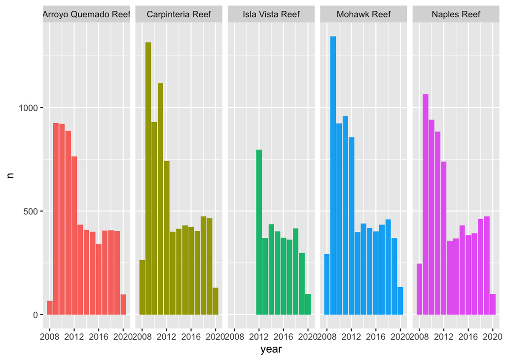

```r
ggplot(data = purple_urchins_tbl, aes(x = year, y = n, fill = site_full)) + geom_col() + facet_grid(~site_full) + theme(legend.position = "none")
```